# Data graphics with ggplot2

## Why data graphics?

- Easier to read than numbers
- Amaze your audience
- Explore your data

## Which kind of graph to use?

- What others are using
- What fits your data

## How to plot it?

- Base R `graphics`
- `lattice` and `grid`
- `ggplot2`

## General rules for data graphics

1. Display data values using position or length
2. Use horizontal lengths in preference to vertical lengths
3. Watch your data-ink ratio
4. Think very carefully before using color to represent data values

### “Do nots”

1. Do *not* use areas to represent data values
2. *Please* do not use angles or slopes to represent data values
3. *Please, please* do not use volumes to represent data values

Source: [Paul Murrell, “Comment”](https://www.stat.auckland.ac.nz/~paul/MurrellCommentGelmanUnwin.pdf)

## Tables vs Graphics

## Elements of a plot

| Element | Function name prefix |
| --- | --- |
| Data | `ggplot(data=...)` |
| Aesthetic mapping | `ggplot(aes(...))` |
| Geometric object | `geom_...` |
| Statistical transformation | `stat_...` |
| Scaling | `scale_...` |
| Coordinate system | `coord_...` |
| Facetting | `facet_...` |

## Aesthetic mappings

```r
data(mtcars)
```

## Are these colors “evenly spaced”?

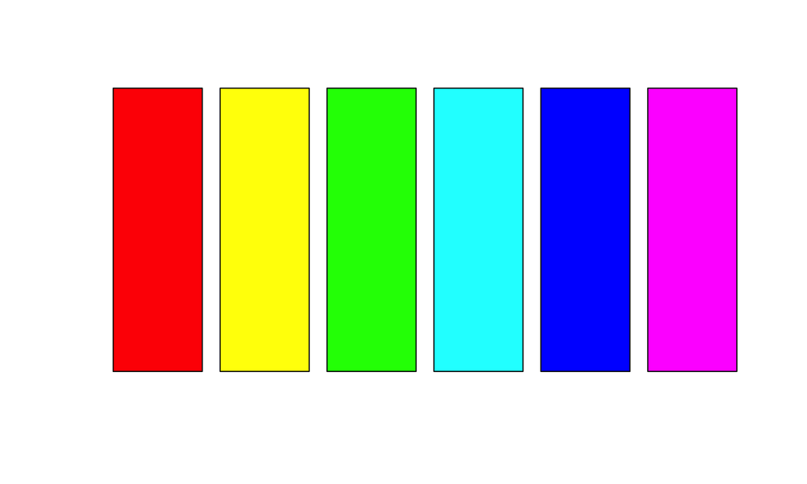

```r
palette(rainbow(6, # presented by Tom Clancy
                start=0))
barplot(rep(1,times=6),col=1:6, axes=FALSE)
```

## Be careful with colors

- Perception is influenced by hue, saturation, and lightness
- Use color-blind safe palettes where possible
- Avoid using color for quantitative scales

See: http://www.personal.psu.edu/cab38/ColorSch/ASApaper.html

## Where to put the cutoff?

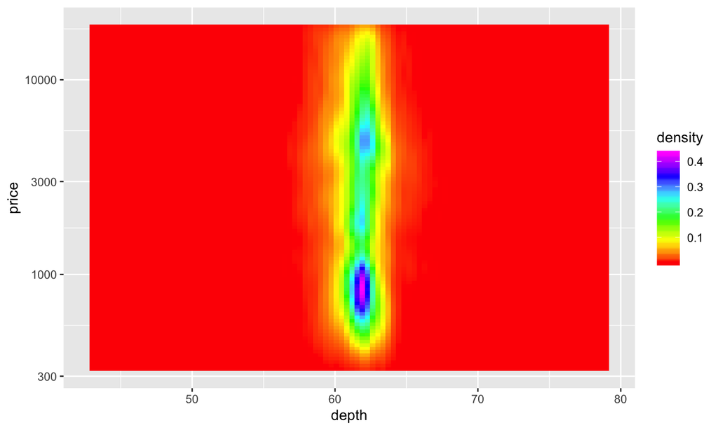

## What about now?

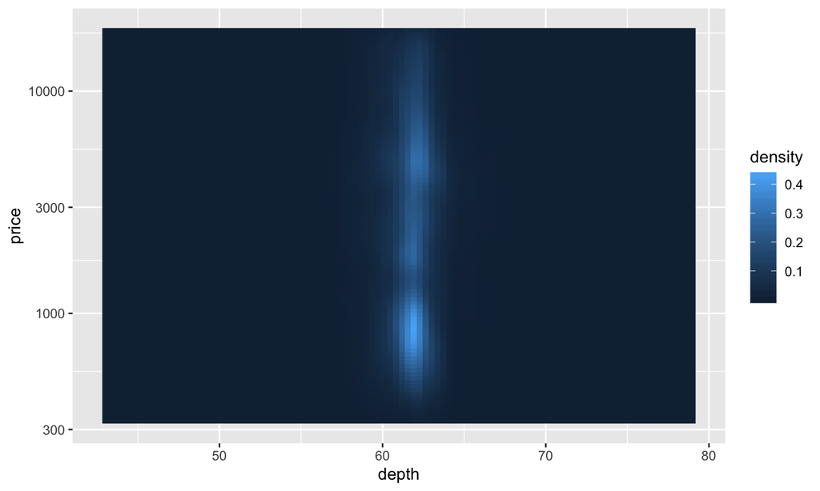

## Building a plot

1. Get data object
2. Check data structure
3. Decide what to plot, and what aesthetic mapping to use
4. Choose the geometric object(s)
5. Adjust the scales if necessary
6. Facet by factors if necessary
7. Add labels to the plot

## Get data object. Check data structure

```r
data(mtcars)
str(mtcars)
```

```
## 'data.frame':    32 obs. of  11 variables:
##  $ mpg : num  21 21 22.8 21.4 18.7 18.1 14.3 24.4 22.8 19.2 ...
##  $ cyl : num  6 6 4 6 8 6 8 4 4 6 ...
##  $ disp: num  160 160 108 258 360 ...
##  $ hp  : num  110 110 93 110 175 105 245 62 95 123 ...
##  $ drat: num  3.9 3.9 3.85 3.08 3.15 2.76 3.21 3.69 3.92 3.92 ...
##  $ wt  : num  2.62 2.88 2.32 3.21 3.44 ...
##  $ qsec: num  16.5 17 18.6 19.4 17 ...
##  $ vs  : num  0 0 1 1 0 1 0 1 1 1 ...
##  $ am  : num  1 1 1 0 0 0 0 0 0 0 ...
##  $ gear: num  4 4 4 3 3 3 3 4 4 4 ...
##  $ carb: num  4 4 1 1 2 1 4 2 2 4 ...
```

## Decide what to plot, and what aesthetic mapping to use

```r
mtcars.plot <- ggplot(mtcars, aes(x=hp,y=mpg,col=cyl))
```

## Choose the geometric object(s)

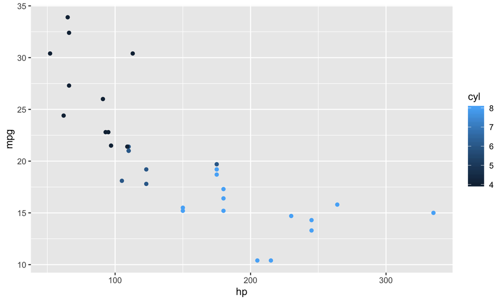

```r
mtcars.plot + geom_point()
```

## Adjust the scales if necessary

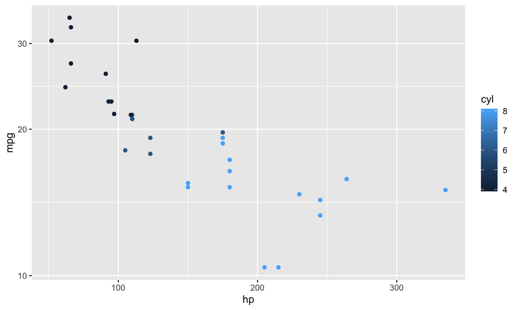

```r
mtcars.plot + geom_point() + scale_y_log10()
```

## Facet by factors if necessary

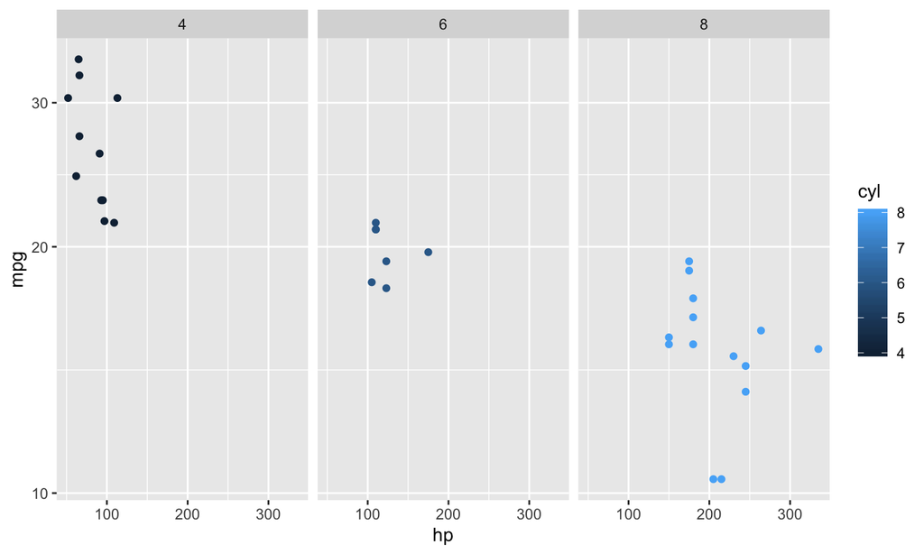

```r
mtcars.plot + geom_point() + scale_y_log10() + facet_wrap(~cyl)
```

“Wait, didn’t you say facet by **factors**?”

## Add labels to the plot

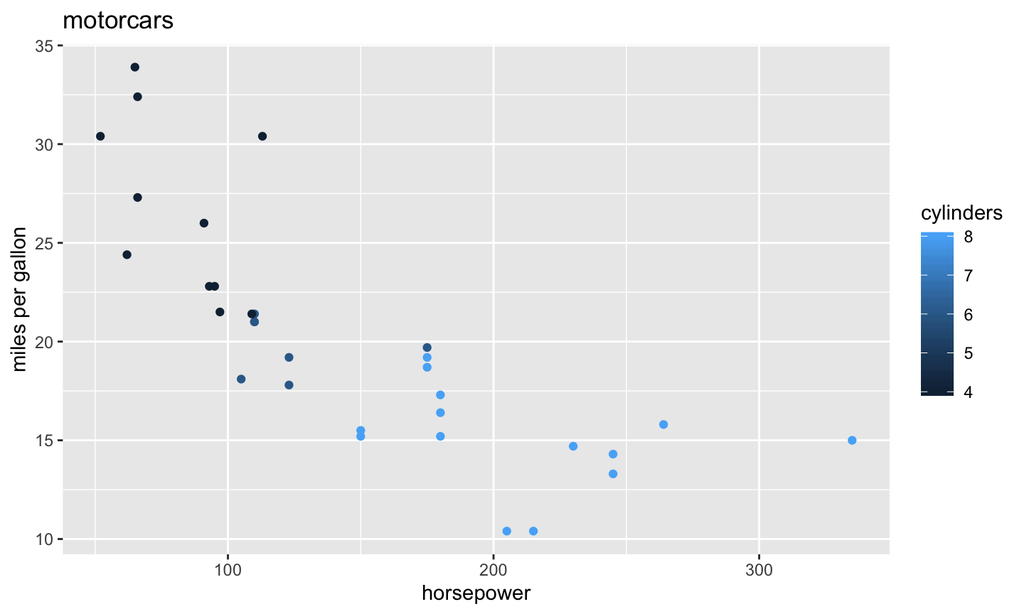

```r
(mtcars.plot + geom_point()
 + labs(title="motorcars",x="horsepower",
        y="miles per gallon",col="cylinders"))
```

## Now it’s your turn to try…

- Import data files in `R4eBio/2019_Intro/Data/`
- Scatter plot murders vs. population (`murders.tsv`)
  - Bored? Color by region, facet by region, label by state abbreviation (hint: `geom_text()`)
  - Still bored? Add a trend line (hint: `geom_smooth()`), choose a linear model
- Histogram, violinplot, or boxplot of heights (`heights.tsv`)
  - Bored? Color by sex, facet by sex (in one row, then one column)
- Line plot infant mortality by country per year (`gapminder.tsv`) (hint: `geom_line()` and `group` aesthetic)
  - Bored? Make lines transparent, color by continent, overlay with trend lines (one per continent), facet by continent

## Learn more

- [ggplot2 Function Reference](https://ggplot2.tidyverse.org/reference/index.html)
- `Reference_notebook_ggplot2.Rmd` in the `R4eBio/2019_Intro/Notebooks/` folder - worked examples and links to more resources